# R Programming

## join( )

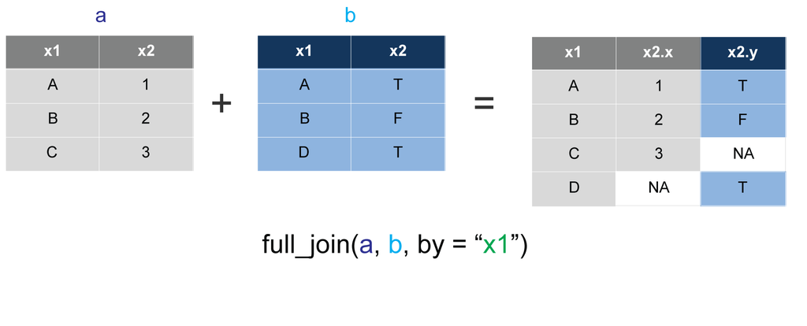

*Join data. Retain all values, all rows.*

## join( )

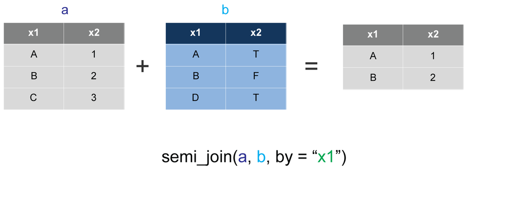

*Keep all rows in `a` that have a match in `b`.*

## join( )

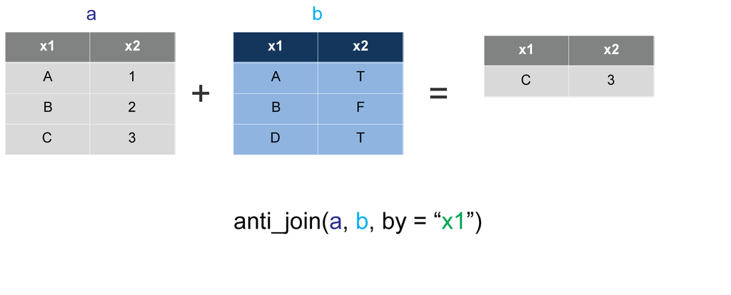

*Keep all rows in `a` that do not have a match in `b`.*

## join( )

Additional `dplyr` functions for merging data sets:

|  | `intersect(y, z)` | Rows that appear in both y and z |
| --- | --- | --- |
|  | `union(y, z)` | Rows that appear in either or both y and z |
|  | `setdiff(y, z)` | Rows that appear in y but not z |
|  | `bind_rows(y, z)` | Append z to y as new rows |
|  | `bind_cols(y, z)` | Append z to y as new columns |

*Use extreme caution when applying `bind_` functions.*

## Your Turn

Import the `reddit.csv` and `regions.csv` files in the data folder

> Join the `regions` data to the `reddit` data

**HINT:** the common variable between the two data frames is `state`

## Key Things to Remember

## Remember These Functions!

`dplyr` is a package that transforms and manipulates data

`select()`: select variables of concern

`filter()`: filter values based on conditions

`group_by()`: group data by categorical levels

`summarise()`: change unit of analysis

`arrange()`: order the data

## Remember These Functions!

`dplyr` is a package that transforms and manipulates data

`mutate()`: create new variables

`join()`: combine separate data sets

## Break

5 minutes!